# TF-IDF 文字探勘 — 以NBA Ptt鄉民回文為例

Josh Chang

2018/4/5

# 主題介紹

TF-IDF 為一種文字探勘處理的工具，使用 TF 詞頻 (Term Frequency)和 IDF 逆向文件頻率 (Inverse Document Frequent)的乘積，得出權重(Weight)，讓使用的人可以在多個文件中找到頻詞高，且在各個文件中“較為獨特”的文字。

而在這次的練習中，我參考了助教給的網站的概念，觀察ptt鄉民對於今年三位MVP呼聲最高球員，Curry, Lebron, Harden，

看看他們分別被討論的關注度和時間點，以及鄉民們對他們有著什麼樣的回應和評論，那就讓我們繼續往下看吧～～

## 1.載入套件包

```r
library(bitops)
library(httr)
library(RCurl)
library(XML)
library(NLP)
library(tm)
library(tmcn)
library(jiebaRD)
library(jiebaR)
library(dplyr)
```

## 2.爬下所需的Ptt網站網址和標題

```r
data <- list()
title <- list()
date <- list()

#抓取三月ptt NBA版的貼文
for( i in c(5702:5794)){
  tmp <- paste(i, '.html', sep='')
  url <- paste('www.ptt.cc/bbs/NBA/index', tmp, sep='')
  html <- htmlParse(GET(url),encoding = "UTF-8")
  title.list <- xpathSApply(html, "//div[@class='title']/a[@href]", xmlValue)
  url.list <- xpathSApply(html, "//div[@class='title']/a[@href]", xmlAttrs)
  date.list <- xpathSApply(html, "//div[@class='meta']/div[@class='date']", xmlValue)
  data <- rbind(data, as.matrix(paste('www.ptt.cc', url.list, sep='')))
  title <- rbind(title, as.matrix(title.list))
  date <- rbind(date, as.matrix(date.list))
}

# data 存網址  title 存標題 #date 存時間
data <- unlist(data)
title <- unlist(title)
date <- unlist(date)
```

### 遇到的小問題(已解決)

原本用getURL 結果發現url.list裡面是NULL 改用GET後就正確了

## 3.找出有相對應關鍵字的標題

```r
Lebron <- c()
Lebron.url <- c()
Lebron.date <- c()

# 找出有關鍵字的標題並分類
lebron1 <- grep("James", title)
lebron2 <- grep("LBJ", title)
lebron3 <- grep("姆斯", title)

Lebron <- c(Lebron,title[lebron1])
Lebron <- c(Lebron,title[lebron2])
Lebron <- c(Lebron,title[lebron3])

Lebron.url <- c(Lebron.url, data[lebron1])
Lebron.url <- c(Lebron.url, data[lebron2])
Lebron.url <- c(Lebron.url, data[lebron3])

Lebron.date <- c(Lebron.date, date[lebron1])
Lebron.date <- c(Lebron.date, date[lebron2])
Lebron.date <- c(Lebron.date, date[lebron3])

Curry <- c()
Curry.url <- c()
Curry.date <- c()

# 找出有關鍵字的標題並分類
curry1 <- grep("Curry", title)
curry2 <- grep("柯瑞", title)
curry3 <- grep("咖哩", title)

Curry <- c(Curry,title[curry1])
Curry <- c(Curry,title[curry2])
Curry <- c(Curry,title[curry3])

Curry.url <- c(Curry.url, data[curry1])
Curry.url <- c(Curry.url, data[curry2])
Curry.url <- c(Curry.url, data[curry3])

Curry.date <- c(Curry.date, date[curry1])
Curry.date <- c(Curry.date, date[curry2])
Curry.date <- c(Curry.date, date[curry3])

Harden <- c()
Harden.url <- c()
Harden.date <- c()

# 找出有關鍵字的標題並分類
harden1 <- grep("Harden", title)
harden2 <- grep("哈登", title)

Harden <- c(Harden,title[harden1])
Harden <- c(Harden,title[harden2])

Harden.url <- c(Harden.url, data[harden1])
Harden.url <- c(Harden.url, data[harden2])

Harden.date <- c(Harden.date, date[harden1])
Harden.date <- c(Harden.date, date[harden2])
```

## 4. 留言擷取 分類 文本清理和建立文本矩陣 TermDocumentMatrix

```r
message <- list()
cc = worker()
LBJTDF <- data.frame()
SCTDF <- data.frame()
JHTDF <- data.frame()
player <- c()
postdate <- c()
hot <- c()

#爬取每篇有姆斯 LBJ 或是James 文章的留言
for(i in c(1:length(Lebron))){
  html <- htmlParse(GET(Lebron.url[i]),encoding = "UTF-8")
  message.list <- xpathSApply(html, "//div[@class='push']/span[@class='f3 push-content']", xmlValue)
  message <- unlist(message.list)

  #日期分類
  player <- c(player,"LBJ")
  if(grepl("3/0",Lebron.date[i])== TRUE){
    postdate <- c(postdate, "3/01~3/09") }
  else if(grepl("3/1",Lebron.date[i])== TRUE){
    postdate <- c(postdate, "3/10~3/19")}
  else if(grepl("3/2",Lebron.date[i])== TRUE){
    postdate <- c(postdate, "3/20~3/29")}
  else if(grepl("3/3",Lebron.date[i])== TRUE){
    postdate <- c(postdate, "3/30~3/31")}


  if(length(message) > 100){
    hot <- c(hot, "Boom!")}
  else if(length(message) > 75){
    hot <- c(hot, "Hot")}
  else if(length(message) > 50){
    hot <- c(hot, "Soso")}
  else{
    hot <- c(hot, "Cold") }



  #文本清理
  d.corpus <- VCorpus( VectorSource(message) )
  d.corpus <- tm_map(d.corpus, removePunctuation)
  d.corpus <- tm_map(d.corpus, removeNumbers)
  d.corpus <- tm_map(d.corpus, function(word) {
    gsub("[A-Za-z0-9]", "", word)
  })

  #斷詞
  abc <- data.frame(table(cc[as.character(d.corpus)]))
  colnames(abc) <- c("word", as.character(i))

  #合併
  if(i == 1){
    LBJTDF <- abc}
  else{
    LBJTDF <- merge(LBJTDF, abc, by = "word", all = T)}
}

#爬取每篇有柯瑞 咖哩 或是Curry 文章的留言
for(i in c(1:length(Curry))){
  html <- htmlParse(GET(Curry.url[i]),encoding = "UTF-8")
  message.list <- xpathSApply(html, "//div[@class='push']/span[@class='f3 push-content']", xmlValue)
  message <- unlist(message.list)

  #日期分類
  player <- c(player,"Curry")
  if(grepl("3/0",Curry.date[i])== TRUE){
    postdate <- c(postdate, "3/01~3/09") }
  else if(grepl("3/1",Curry.date[i])== TRUE){
    postdate <- c(postdate, "3/10~3/19")}
  else if(grepl("3/2",Curry.date[i])== TRUE){
    postdate <- c(postdate, "3/20~3/29")}
  else if(grepl("3/3",Curry.date[i])== TRUE){
    postdate <- c(postdate, "3/30~3/31")}


  #人氣分類
  if(length(message) > 100){
    hot <- c(hot, "Boom!")}
  else if(length(message) > 75){
    hot <- c(hot, "Hot")}
  else if(length(message) > 50){
    hot <- c(hot, "Soso")}
  else{
    hot <- c(hot, "Cold") }

   #文本清理
  d.corpus <- VCorpus( VectorSource(message) )
  d.corpus <- tm_map(d.corpus, removePunctuation)
  d.corpus <- tm_map(d.corpus, removeNumbers)
  d.corpus <- tm_map(d.corpus, function(word) {
    gsub("[A-Za-z0-9]", "", word)
  })

  #斷詞
  abc <- data.frame(table(cc[as.character(d.corpus)]))
  colnames(abc) <- c("word", as.character(i))

  #合併
  if(i == 1){
    SCTDF <- abc}
  else{
    SCTDF <- merge(SCTDF, abc, by = "word", all = T)}
}

#爬取每篇有哈登或是Harden文章的留言
for(i in c(1:length(Harden))){
  html <- htmlParse(GET(Harden.url[i]),encoding = "UTF-8")
  message.list <- xpathSApply(html, "//div[@class='push']/span[@class='f3 push-content']", xmlValue)
  message <- unlist(message.list)

  #日期分類
  player <- c(player,"Harden")
  if(grepl("3/0",Harden.date[i])== TRUE){
    postdate <- c(postdate, "3/01~3/09") }
  else if(grepl("3/1",Harden.date[i])== TRUE){
    postdate <- c(postdate, "3/10~3/19")}
  else if(grepl("3/2",Harden.date[i])== TRUE){
    postdate <- c(postdate, "3/20~3/29")}
  else if(grepl("3/3",Harden.date[i])== TRUE){
    postdate <- c(postdate, "3/30~3/31")}

  #人氣分類
  if(length(message) > 100){
    hot <- c(hot, "Boom!")}
  else if(length(message) > 75){
    hot <- c(hot, "Hot")}
  else if(length(message) > 50){
    hot <- c(hot, "Soso")}
  else{
    hot <- c(hot, "Cold") }

  #文本清理
  d.corpus <- VCorpus( VectorSource(message) )
  d.corpus <- tm_map(d.corpus, removePunctuation)
  d.corpus <- tm_map(d.corpus, removeNumbers)
  d.corpus <- tm_map(d.corpus, function(word) {
    gsub("[A-Za-z0-9]", "", word)
  })

  #斷詞
  abc <- data.frame(table(cc[as.character(d.corpus)]))
  colnames(abc) <- c("word", as.character(i))

  #合併
  if(i == 1){
    JHTDF <- abc}
  else{
    JHTDF <- merge(JHTDF, abc, by = "word", all = T)}
}



#將遺漏值設為 0
LBJTDF[is.na(LBJTDF)] <- 0
JHTDF[is.na(JHTDF)] <- 0
SCTDF[is.na(SCTDF)] <- 0

library(knitr)
kable(head(LBJTDF))
```

| word | 1 | 2 | 3 | 4 | 5 | 6 | 7 | 8 | 9 | 10 | 11 | 12 | 13 | 14 | 15 | 16 | 17 | 18 | 19 | 20 | 21 | 22 | 23 | 24 | 25 | 26 | 27 | 28 | 29 | … |
| --- | --- | --- | --- | --- | --- | --- | --- | --- | --- | --- | --- | --- | --- | --- | --- | --- | --- | --- | --- | --- | --- | --- | --- | --- | --- | --- | --- | --- | --- | --- |
| 阿 | 2 | 0 | 6 | 6 | 0 | 1 | 4 | 0 | 0 | 2 | 16 | 10 | 3 | 1 | 1 | 1 | 0 | 3 | 2 | 3 | 1 | 0 | 0 | 2 | 0 | 1 | 0 | 2 | 7 | … |
| 啊 | 1 | 7 | 12 | 13 | 0 | 1 | 2 | 1 | 1 | 2 | 46 | 40 | 13 | 1 | 2 | 4 | 2 | 5 | 6 | 2 | 2 | 4 | 0 | 15 | 2 | 4 | 3 | 12 | 20 | … |
| 吧 | 2 | 16 | 7 | 4 | 0 | 2 | 5 | 0 | 3 | 0 | 35 | 25 | 7 | 9 | 1 | 5 | 2 | 6 | 3 | 3 | 3 | 5 | 1 | 18 | 1 | 1 | 0 | 8 | 7 | … |
| 白鬍子 | 2 | 0 | 0 | 0 | 0 | 0 | 0 | 0 | 0 | 0 | 0 | 0 | 0 | 0 | 0 | 0 | 0 | 0 | 0 | 0 | 0 | 0 | 0 | 0 | 0 | 0 | 0 | 0 | 0 | … |
| 辦法 | 1 | 0 | 1 | 2 | 0 | 0 | 0 | 0 | 0 | 0 | 4 | 3 | 0 | 0 | 0 | 0 | 0 | 0 | 0 | 1 | 0 | 0 | 1 | 0 | 0 | 0 | 0 | 0 | 1 | … |
| 被 | 3 | 2 | 20 | 8 | 0 | 0 | 4 | 5 | 6 | 5 | 39 | 22 | 14 | 3 | 4 | 3 | 0 | 2 | 8 | 6 | 1 | 8 | 0 | 13 | 1 | 2 | 2 | 2 | 19 | … |

```r
kable(head(SCTDF))
```

| word | 1 | 2 | 3 | 4 | 5 | 6 | 7 | 8 | 9 | 10 | 11 | 12 | 13 | 14 | 15 | 16 | 17 | 18 | 19 | 20 | 21 | 22 | 23 | 24 | 25 | 26 | 27 | 28 | 29 | … |
| --- | --- | --- | --- | --- | --- | --- | --- | --- | --- | --- | --- | --- | --- | --- | --- | --- | --- | --- | --- | --- | --- | --- | --- | --- | --- | --- | --- | --- | --- | --- |
| 阿 | 1 | 8 | 0 | 1 | 0 | 0 | 0 | 1 | 1 | 2 | 0 | 2 | 3 | 8 | 1 | 0 | 1 | 0 | 1 | 0 | 1 | 1 | 16 | 0 | 0 | 0 | 0 | 0 | 0 | … |
| 啊 | 4 | 37 | 2 | 4 | 0 | 3 | 1 | 2 | 2 | 2 | 0 | 3 | 8 | 16 | 2 | 2 | 4 | 5 | 1 | 1 | 10 | 10 | 18 | 3 | 1 | 1 | 4 | 2 | 3 | … |
| 欸 | 1 | 9 | 0 | 1 | 0 | 0 | 2 | 0 | 0 | 0 | 0 | 0 | 0 | 0 | 0 | 0 | 0 | 0 | 0 | 1 | 1 | 0 | 0 | 0 | 0 | 0 | 1 | 1 | 0 | … |
| 暗號 | 1 | 0 | 0 | 0 | 0 | 0 | 0 | 0 | 0 | 0 | 0 | 0 | 0 | 0 | 0 | 0 | 0 | 0 | 0 | 0 | 0 | 1 | 0 | 0 | 0 | 0 | 0 | 0 | 0 | … |
| 吧 | 1 | 23 | 1 | 2 | 1 | 9 | 9 | 0 | 3 | 2 | 0 | 2 | 14 | 24 | 2 | 3 | 6 | 5 | 5 | 0 | 5 | 3 | 19 | 3 | 3 | 0 | 9 | 4 | 1 | … |
| 白癡 | 1 | 0 | 0 | 0 | 0 | 0 | 0 | 0 | 0 | 0 | 0 | 0 | 0 | 0 | 0 | 0 | 0 | 0 | 0 | 0 | 0 | 0 | 0 | 0 | 0 | 0 | 0 | 0 | 0 | … |

```r
kable(head(JHTDF))
```

| word | 1 | 2 | 3 | 4 | 5 | 6 | 7 | 8 | 9 | 10 | 11 | 12 | 13 | 14 | 15 | 16 | 17 | 18 | 19 | 20 | 21 | 22 | 23 | 24 | 25 | 26 | 27 | 28 | 29 | … |
| --- | --- | --- | --- | --- | --- | --- | --- | --- | --- | --- | --- | --- | --- | --- | --- | --- | --- | --- | --- | --- | --- | --- | --- | --- | --- | --- | --- | --- | --- | --- |
| 阿 | 1 | 0 | 0 | 2 | 0 | 0 | 1 | 2 | 0 | 0 | 0 | 1 | 0 | 0 | 1 | 7 | 1 | 0 | 3 | 3 | 2 | 6 | 0 | 0 | 0 | 2 | 0 | 0 | 0 | … |
| 啊 | 1 | 3 | 1 | 1 | 0 | 0 | 1 | 4 | 0 | 1 | 4 | 6 | 1 | 1 | 8 | 13 | 8 | 5 | 11 | 8 | 4 | 11 | 1 | 3 | 5 | 2 | 4 | 0 | 2 | … |
| 拔 | 1 | 0 | 0 | 0 | 0 | 0 | 0 | 0 | 0 | 0 | 0 | 0 | 0 | 0 | 0 | 0 | 0 | 0 | 0 | 0 | 0 | 0 | 0 | 0 | 0 | 0 | 0 | 0 | 0 | … |
| 把 | 2 | 1 | 0 | 0 | 0 | 0 | 0 | 1 | 0 | 2 | 0 | 1 | 0 | 0 | 1 | 1 | 2 | 0 | 2 | 1 | 0 | 4 | 0 | 3 | 3 | 1 | 0 | 0 | 0 | … |
| 爸 | 1 | 0 | 0 | 0 | 0 | 0 | 0 | 0 | 0 | 0 | 0 | 0 | 0 | 0 | 0 | 0 | 0 | 0 | 0 | 0 | 0 | 0 | 0 | 0 | 0 | 0 | 0 | 0 | 0 | … |
| 爸爸 | 4 | 0 | 0 | 0 | 0 | 0 | 0 | 0 | 0 | 0 | 0 | 0 | 0 | 0 | 0 | 0 | 0 | 0 | 0 | 0 | 0 | 0 | 0 | 0 | 0 | 0 | 0 | 0 | 0 | … |

## 5. 將已建好的 TDM 轉成 TF-IDF

```r
n <- length(Lebron)
tf1 <- apply(as.matrix(LBJTDF[,2:(n+1)]), 2, sum)
library(Matrix)
idfCal1 <- function(word_doc)
{
  log2( n / nnzero(word_doc) )
}
idf1 <- apply(as.matrix(LBJTDF[,2:(n+1)]), 1, idfCal1)

doc1.tfidf <- LBJTDF

for(x in 1:nrow(LBJTDF))
{
  for(y in 2:ncol(LBJTDF))
  {
    doc1.tfidf[x,y] <- (doc1.tfidf[x,y] / tf1[y-1]) * idf1[x]
  }
}

n <- length(Curry)
tf2 <- apply(as.matrix(SCTDF[,2:(n+1)]), 2, sum)

idfCal2 <- function(word_doc)
{
  log2( n / nnzero(word_doc) )
}
idf2 <- apply(as.matrix(SCTDF[,2:(n+1)]), 1, idfCal2)

doc2.tfidf <- SCTDF

for(x in 1:nrow(SCTDF))
{
  for(y in 2:ncol(SCTDF))
  {
    doc2.tfidf[x,y] <- (doc2.tfidf[x,y] / tf2[y-1]) * idf2[x]
  }
}

n <- length(Harden)
tf3 <- apply(as.matrix(JHTDF[,2:(n+1)]), 2, sum)
idfCal3 <- function(word_doc)
{
  log2( n / nnzero(word_doc) )
}
idf3 <- apply(as.matrix(JHTDF[,2:(n+1)]), 1, idfCal3)

doc3.tfidf <- JHTDF

for(x in 1:nrow(JHTDF))
{
  for(y in 2:ncol(JHTDF))
  {
    doc3.tfidf[x,y] <- (doc3.tfidf[x,y] / tf3[y-1]) * idf3[x]
  }
}
```

## 6.列出文章留言中的最重要詞彙

### 6-1 Lebron James 文章重要詞彙

```r
topwords <- subset(head(doc1.tfidf[order(doc1.tfidf[2], decreasing = TRUE), ]), select = c(word))
for (i in c(3:ncol(doc1.tfidf))){
  topwords <- cbind(topwords, head(doc1.tfidf[order(doc1.tfidf[i], decreasing = TRUE),])[1])
}


AllTop = as.data.frame( table(as.matrix(topwords)) )
AllTop = AllTop[order(AllTop$Freq, decreasing = TRUE),]

kable(head(AllTop))
```

|  | Var1 | Freq |
| --- | --- | --- |
| 389 | 曇花 | 7 |
| 20 | 保養 | 5 |
| 396 | 體能 | 5 |
| 80 | 得分 | 4 |
| 335 | 人品 | 4 |
| 402 | 統治力 | 4 |

### 6-2 Stephen Curry 文章重要詞彙

```r
topwords <- subset(head(doc2.tfidf[order(doc2.tfidf[2], decreasing = TRUE), ]), select = c(word))
for (i in c(3:ncol(doc2.tfidf))){
  topwords <- cbind(topwords, head(doc2.tfidf[order(doc2.tfidf[i], decreasing = TRUE),])[1])
}

AllTop = as.data.frame( table(as.matrix(topwords)) )
AllTop = AllTop[order(AllTop$Freq, decreasing = TRUE),]

kable(head(AllTop))
```

|  | Var1 | Freq |
| --- | --- | --- |
| 21 | 笨拙 | 5 |
| 17 | 報應 | 3 |
| 31 | 不讓 | 3 |
| 32 | 不是故意 | 3 |
| 105 | 火箭 | 3 |
| 257 | 早日康復 | 3 |

### 6-3 James Harden 文章重要詞彙

```r
topwords <- subset(head(doc3.tfidf[order(doc3.tfidf[2], decreasing = TRUE), ]), select = c(word))
for (i in c(3:ncol(doc3.tfidf))){
  topwords <- cbind(topwords, head(doc3.tfidf[order(doc3.tfidf[i], decreasing = TRUE),])[1])
}

AllTop = as.data.frame( table(as.matrix(topwords)) )
AllTop = AllTop[order(AllTop$Freq, decreasing = TRUE),]

kable(head(AllTop))
```

|  | Var1 | Freq |
| --- | --- | --- |
| 53 | 犯規 | 4 |
| 200 | 戰績 | 3 |
| 211 | 走步 | 3 |
| 2 | 阿泰 | 2 |
| 36 | 單打 | 2 |
| 42 | 地雷 | 2 |

## 7. 發文日期和發文量

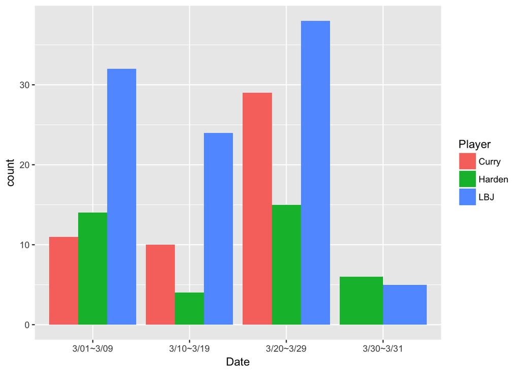

```r
library(ggplot2)
df1 <- data.frame(player,postdate,hot)

names(df1) <- c("Player", "Date", "Popularity")
ggplot(df1, aes(Date,fill = Player)) + geom_bar(position="dodge")
```

## 8. 球員被討論的熱門程度

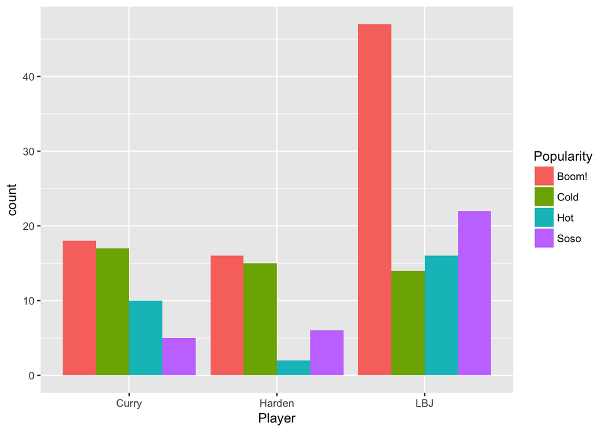

```r
ggplot(df1, aes(Player,fill = Popularity)) + geom_bar(position="dodge")
```

## 9. 結論

這次TFIDF的分析 讓我看到 Lebron Harden Curry這三位現今NBA頂級球員 在台灣最大的論壇ptt中 鄉民們最常以甚麼詞語來評論他們 也可以從這些詞語中看出 最近他們身處什麼議題 和最近的表現如何

像是Lebron的體能 統治力 得分 可知道即使現在他已經33歲了 仍然是NBA的賽場上的霸主

而Curry的早日康復 知道最近Curry受到傷勢困擾 也造成他在3月底的關注度減少(3/8 3/22為其受傷的日子 故文章較多)

最後 Harden的犯規 戰績 走步 也很符合他一貫的形象 也知道今年火箭的戰績(西區第一)廣大被鄉民討論

而在爬蟲的過程中 我也將有關球員文章的留言數 知道這三位好手的人氣

儘管他們三人都非常紅 但很明顯 Lebron James仍然是目前NBA的第一人(從發文數跟留言量都可知)

硬要說 TFIDF 有什麼缺點 可能是在當資料過多(像此次處理一個月的文章)時 繁複的計算會導致時間偏慢 但其演算法去除贅字的能力 仍讓我大開眼界 希望將來能有更多的時間 對這個演算法有更深入的研究！